# Reproducible Research Peer Assignment - Storm Data

Lora Lennertz

March 5, 2018

## NOAA Storm Weather Data Analysis

This is an analysis of the NOAA storm data. The data for this analysis came in the form of a comma-separated-value file compressed via the bzip2 at https://d396qusza40orc.cloudfront.net/repdata%2Fdata%2FStormData.csv.bz2. Information on the data is available at the FAQ page https://d396qusza40orc.cloudfront.net/repdata%2Fpeer2_doc%2FNCDC%20Storm%20Events-FAQ%20Page.pdf while information on variables is available at https://d396qusza40orc.cloudfront.net/repdata%2Fpeer2_doc%2Fpd01016005curr.pdf

## Synopsis

My analysis uses storm data from the NOAA National Weather Service listed above. This data was collected between 1950 - 2011 to study which weather events effect human injuries and fatalities and those responsible for high levels of property and crop damage. The data were reviewed. Due to input anomalies, weather categories were applied. Impact in the areas of injuries, fatalities and costs were summed on these categories. Some findings from this analysis include:

[output not shown]

## Data processing

Load Data libraries for analysis and graphing

```r
# Loading libraries for data analyisis and data plotting
library (dplyr)
library (ggplot2)
```

Load Data and create dataframe

```r
# Load data set and make initial dataframe
if(!exists("StormData")){
  download.file("https://d396qusza40orc.cloudfront.net/repdata%2Fdata%2FStormData.csv.bz2", "repdata-data-StormData.csv.bz2")
  StormData <- read.csv ("repdata-data-StormData.csv.bz2")
}
```

Let’s investigate the variable information

```r
#Investigating StormData variables
names(StormData)
```

```
##  [1] "STATE__"    "BGN_DATE"   "BGN_TIME"   "TIME_ZONE"  "COUNTY"
##  [6] "COUNTYNAME" "STATE"      "EVTYPE"     "BGN_RANGE"  "BGN_AZI"
## [11] "BGN_LOCATI" "END_DATE"   "END_TIME"   "COUNTY_END" "COUNTYENDN"
## [16] "END_RANGE"  "END_AZI"    "END_LOCATI" "LENGTH"     "WIDTH"
## [21] "F"          "MAG"        "FATALITIES" "INJURIES"   "PROPDMG"
## [26] "PROPDMGEXP" "CROPDMG"    "CROPDMGEXP" "WFO"        "STATEOFFIC"
## [31] "ZONENAMES"  "LATITUDE"   "LONGITUDE"  "LATITUDE_E" "LONGITUDE_"
## [36] "REMARKS"    "REFNUM"
```

```r
head(StormData)
```

```
##   STATE__           BGN_DATE BGN_TIME TIME_ZONE COUNTY COUNTYNAME STATE
## 1       1  4/18/1950 0:00:00     0130       CST     97     MOBILE    AL
## 2       1  4/18/1950 0:00:00     0145       CST      3    BALDWIN    AL
## 3       1  2/20/1951 0:00:00     1600       CST     57    FAYETTE    AL
## 4       1   6/8/1951 0:00:00     0900       CST     89    MADISON    AL
## 5       1 11/15/1951 0:00:00     1500       CST     43    CULLMAN    AL
## 6       1 11/15/1951 0:00:00     2000       CST     77 LAUDERDALE    AL
##    EVTYPE BGN_RANGE BGN_AZI BGN_LOCATI END_DATE END_TIME COUNTY_END
## 1 TORNADO         0                                               0
## 2 TORNADO         0                                               0
## 3 TORNADO         0                                               0
## 4 TORNADO         0                                               0
## 5 TORNADO         0                                               0
## 6 TORNADO         0                                               0
##   COUNTYENDN END_RANGE END_AZI END_LOCATI LENGTH WIDTH F MAG FATALITIES
```

[output cut: 20 more lines]

We will begin by segmenting the data to create two smaller datasets – one for analysing injuries and fatalities and one for working with economic data

```r
#Begin data processing - create dataframe  subset for injuries and fatalities and for damages
Fatal <- subset(StormData, FATALITIES> 0 | INJURIES>0)
EconData <- subset(StormData, PROPDMG > 0 |  CROPDMG > 0)
```

We will now begin processing the fatalities and injury data to get a brief look at the results

```r
#Sum and sort fatalities
Fatal <- Fatal[order(Fatal$FATALITIES, decreasing = TRUE),]

total_fatal <- sum(StormData$FATALITIES)
total_injuries <- sum(StormData$INJURIES)

Fatal_sum <- summarise(group_by(Fatal,EVTYPE),FATALITIES = sum(FATALITIES), INJURIES = sum(INJURIES))
Fatal_sum$EVTYPE
```

```
##   [1] AVALANCE                       AVALANCHE
##   [3] BLACK ICE                      BLIZZARD
##   [5] blowing snow                   BLOWING SNOW
##   [7] BRUSH FIRE                     COASTAL FLOOD
##   [9] Coastal Flooding               COASTAL FLOODING
##  [11] COASTAL FLOODING/EROSION       Coastal Storm
##  [13] COASTAL STORM                  COASTALSTORM
##  [15] Cold                           COLD
##  [17] COLD AND SNOW                  Cold Temperature
##  [19] COLD WAVE                      COLD WEATHER
##  [21] COLD/WIND CHILL                COLD/WINDS
##  [23] DENSE FOG                      DROUGHT
##  [25] DROUGHT/EXCESSIVE HEAT         DROWNING
##  [27] DRY MICROBURST                 DRY MIRCOBURST WINDS
##  [29] Dust Devil                     DUST DEVIL
```

[output cut: 96 more lines]

After looking at the EVTYPE variable in this view, it is apparent that the data is not clean and there are issues of spellings and capitalization. To create a cleaner dataset, we will convert the headings to include variations on spellings. In addition some similar events such as rain and hail are gathered together to create 20 headings (including an “other” category). A secondary goal was to limit the “other” category so that the results are a smaller representation of the whole. We are gathering the information into a new variable called CATEGORY.

```r
# We note that the data has a number of issues regarding spelling and capitalization errors
cat_event <- c("ICE|ICY", "FREEZE|FROST", "SNOW|AVALANCHE|WINTER|BLIZZARD|SLEET", "COLD", "DUST", "FLOOD|FLD", "FIRE|WILDFIRE", "RAIN|HAIL", "SURF|WAVE|TSUNAMI|SURGE", "WIND|MICROBURST", "COLD",
               "DROUGHT", "FOG", "HEAT|WARM", "HURRICANE|TYPHOON|TORNADO|TROPICAL", "LIGHTNING", "LAND|SLIDE|MUD", "TIDE|TIDAL", "RAIN|HAIL|DRIZZLE|RAINSTORM", "THUNDERSTORM|TSTM", "WIND|GUST|GUSTY WIND")
Fatal$CATEGORY = "Other"
for(i in cat_event){
  Fatal[grep(i, Fatal$EVTYPE, ignore.case = TRUE ),"CATEGORY"] <- i
}

#Let's create summation tables on the data on fatalities and injuries
Fatal_sum <- summarise(group_by(Fatal,CATEGORY),FATALITIES = sum(FATALITIES))
Fatal_sum <- Fatal_sum[order(Fatal_sum$FATALITIES, decreasing = TRUE),]
Injuries_sum <- summarise(group_by(Fatal,CATEGORY), INJURIES = sum(INJURIES))
Injuries_sum <- Injuries_sum[order(Injuries_sum$INJURIES, decreasing = TRUE),]
print(Fatal_sum)
```

```
## # A tibble: 20 x 2
##    CATEGORY                             FATALITIES
##    <chr>                                     <dbl>
##  1 HURRICANE|TYPHOON|TORNADO|TROPICAL      5835
##  2 HEAT|WARM                               3178
##  3 FLOOD|FLD                               1552
##  4 WIND|GUST|GUSTY WIND                    1451
##  5 LIGHTNING                                817
##  6 SNOW|AVALANCHE|WINTER|BLIZZARD|SLEET     748
##  7 Other                                    637
##  8 COLD                                     229
##  9 SURF|WAVE|TSUNAMI|SURGE                  210
## 10 RAIN|HAIL|DRIZZLE|RAINSTORM              130
## 11 ICE|ICY                                  102
## 12 FIRE|WILDFIRE                             90.0
## 13 FOG                                       81.0
## 14 LAND|SLIDE|MUD                            44.0
## 15 DUST                                      24.0
## 16 TIDE|TIDAL                                11.0
## 17 WIND|MICROBURST                            3.00
## 18 FREEZE|FROST                               2.00
## 19 THUNDERSTORM|TSTM                          1.00
## 20 DROUGHT                                    0
```

```r
print(Injuries_sum)
```

```
## # A tibble: 20 x 2
##    CATEGORY                             INJURIES
##    <chr>                                   <dbl>
##  1 HURRICANE|TYPHOON|TORNADO|TROPICAL   93123
##  2 WIND|GUST|GUSTY WIND                 11498
##  3 HEAT|WARM                             9243
##  4 FLOOD|FLD                             8682
##  5 LIGHTNING                             5231
##  6 SNOW|AVALANCHE|WINTER|BLIZZARD|SLEET  3972
##  7 ICE|ICY                               2183
##  8 RAIN|HAIL|DRIZZLE|RAINSTORM           1691
##  9 FIRE|WILDFIRE                         1608
## 10 FOG                                   1077
## 11 Other                                  907
## 12 DUST                                   483
## 13 SURF|WAVE|TSUNAMI|SURGE                415
## 14 COLD                                   279
## 15 LAND|SLIDE|MUD                          55.0
## 16 THUNDERSTORM|TSTM                       40.0
## 17 WIND|MICROBURST                         28.0
## 18 TIDE|TIDAL                               6.00
## 19 DROUGHT                                  4.00
## 20 FREEZE|FROST                             3.00
```

Now we will begin processing the subset of economic data. We are already aware that there were some incontinuities with the data entry regarding the exponential information (is it hundreds, billions, etc.) as well as the earlier problem with categorizations.

```r
#let's process data for environmental damage


print(unique(EconData$PROPDMGEXP))
```

```
##  [1] K M B m   + 0 5 6 4 h 2 7 3 H -
## Levels:  - ? + 0 1 2 3 4 5 6 7 8 B h H K m M
```

```r
print(unique(EconData$CROPDMGEXP))
```

```
## [1]   M K m B ? 0 k
## Levels:  ? 0 2 B k K m M
```

Here we combine different versions of the exponent fields for both property and crop damage

```r
EXP <- c("1","2|h|H","3|k|K","4","5","6|m|M","7","8","9|b|B")
EconData$PROP_TEN <- 1
EconData$CROP_TEN <- 1
x <- 1
for(i in EXP){
  x <- x * 10
  EconData$PROP_TEN[grep(i, EconData$PROPDMGEXP, ignore.case = TRUE )] <- x
  EconData$CROP_TEN[grep(i, EconData$CROPDMGEXP, ignore.case = TRUE )] <- x
}

DAMAGE<- data.frame(EVTYPE = EconData$EVTYPE, COST = EconData$PROPDMG*EconData$PROP_TEN + EconData$CROPDMG*EconData$CROP_TEN)

#We then aggregate each storm by EVTYPE and categorize each storm so we can get a more accurate aggregation of the damage caused by storms.

DAMAGE_SUM <- summarize(group_by(DAMAGE,EVTYPE), COST = sum(COST))
DAMAGE_SUM <- DAMAGE_SUM[order(DAMAGE_SUM$COST, decreasing = TRUE),]
head(DAMAGE_SUM,20)
```

```
## # A tibble: 20 x 2
##    EVTYPE                            COST
##    <fctr>                           <dbl>
##  1 FLOOD                     150319678257
##  2 HURRICANE/TYPHOON          71913712800
##  3 TORNADO                    57362333946
##  4 STORM SURGE                43323541000
##  5 HAIL                       18761221986
##  6 FLASH FLOOD                18243991078
##  7 DROUGHT                    15018672000
##  8 HURRICANE                  14610229010
##  9 RIVER FLOOD                10148404500
## 10 ICE STORM                   8967041360
## 11 TROPICAL STORM              8382236550
## 12 WINTER STORM                6715441251
## 13 HIGH WIND                   5908617595
## 14 WILDFIRE                    5060586800
## 15 TSTM WIND                   5038935845
## 16 STORM SURGE/TIDE            4642038000
## 17 THUNDERSTORM WIND           3897965522
## 18 HURRICANE OPAL              3191846000
## 19 WILD/FOREST FIRE            3108626330
## 20 HEAVY RAIN/SEVERE WEATHER   2500000000
```

```r
#We see the initial aggregated sums by EVTYPE and make a list of categories search for and combine similar or same storms. Similar terms will used " | " as an OR search function for GREP. For example: “FLOOD|FLD”
DAMAGE_SUM$CATEGORY = "Other"
cat_event <- c("ICE|ICY", "FREEZE|FROST", "SNOW|AVALANCHE|WINTER|BLIZZARD|SLEET", "COLD", "DUST", "FLOOD|FLD", "FIRE|WILDFIRE", "RAIN|HAIL", "SURF|WAVE|TSUNAMI|SURGE", "WIND|MICROBURST", "COLD",
"DROUGHT", "FOG", "HEAT|WARM", "HURRICANE|TYPHOON|TORNADO|TROPICAL", "LIGHTNING", "LAND|SLIDE|MUD", "TIDE|TIDAL", "RAIN|HAIL|DRIZZLE|RAINSTORM", "THUNDERSTORM|TSTM", "WIND|GUST|GUSTY WIND")
for(i in cat_event){
  DAMAGE_SUM[grep(i, DAMAGE_SUM$EVTYPE, ignore.case = TRUE),"CATEGORY"] <- i
}

DAMAGE_SUM2 <- summarize(group_by(DAMAGE_SUM,CATEGORY),COST = sum(COST))
DAMAGE_SUM2 <- DAMAGE_SUM2[order(DAMAGE_SUM2$COST, decreasing = TRUE),]
DAMAGE_SUM2
```

```
## # A tibble: 20 x 2
##    CATEGORY                                     COST
##    <chr>                                       <dbl>
##  1 FLOOD|FLD                            180523303682
##  2 HURRICANE|TYPHOON|TORNADO|TROPICAL   156591830806
##  3 SURF|WAVE|TSUNAMI|SURGE               43569648000
##  4 RAIN|HAIL|DRIZZLE|RAINSTORM           23093252978
##  5 WIND|GUST|GUSTY WIND                  20110622412
##  6 DROUGHT                               15018672000
##  7 ICE|ICY                                8980459860
##  8 FIRE|WILDFIRE                          8899910130
##  9 SNOW|AVALANCHE|WINTER|BLIZZARD|SLEET   8684687851
## 10 TIDE|TIDAL                             4651796150
## 11 FREEZE|FROST                           2016261000
## 12 COLD                                   1534556900
## 13 THUNDERSTORM|TSTM                      1227223550
## 14 LIGHTNING                               947501520
## 15 HEAT|WARM                               924805030
## 16 LAND|SLIDE|MUD                          347476100
## 17 Other                                   165790750
## 18 FOG                                      25011500
## 19 DUST                                      9388130
## 20 WIND|MICROBURST                           6862600
```

# RESULTS

We are now ready to plot the previous charts to emphasize the results visually

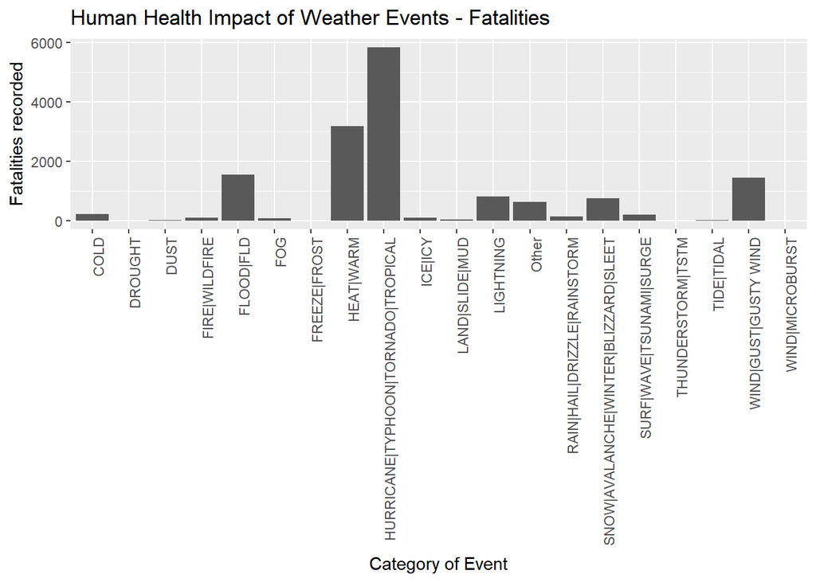

```r
hh.p1 <- ggplot(Fatal_sum,aes(x = CATEGORY, y = FATALITIES)) +
  geom_bar(stat = "identity") +
  theme(axis.text.x = element_text(angle = 90, hjust = 1)) +
  ggtitle("Human Health Impact of Weather Events - Fatalities") +
  xlab("Category of Event") + ylab("Fatalities recorded")

print(hh.p1)
```

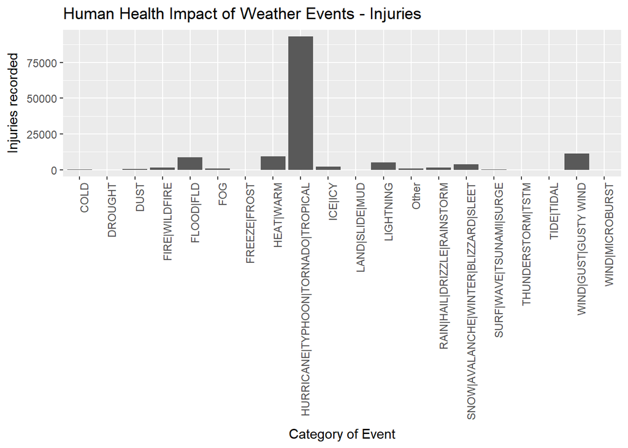

```r
hh.p2 <- ggplot(Injuries_sum,aes(x = CATEGORY, y = INJURIES)) +
  geom_bar(stat = "identity") +
  theme(axis.text.x = element_text(angle = 90, hjust = 1)) +
  ggtitle("Human Health Impact of Weather Events - Injuries") +
  xlab("Category of Event") + ylab("Injuries recorded")

print(hh.p2)
```

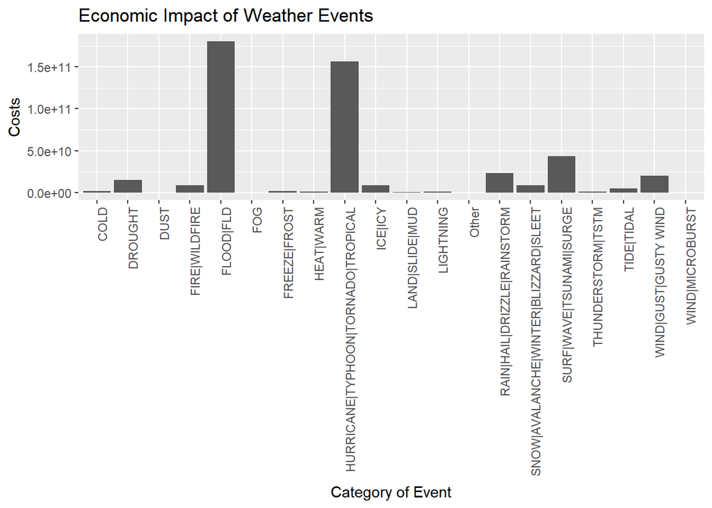

```r
hh.p3 <- ggplot(DAMAGE_SUM2,aes(x = CATEGORY, y = COST)) +
  geom_bar(stat = "identity") +
  theme(axis.text.x = element_text(angle = 90, hjust = 1)) +
  ggtitle("Economic Impact of Weather Events") +
  xlab("Category of Event") + ylab("Costs")

print(hh.p3)
```

# Recommendations for further research

Wind and flood damage seem to be significant sources of fatalities and injuries. It might be of interest to separate out those storm events which are often characterized by high winds and signficant flooding to provide a clearer picture of the human impact of wind and water.